# Motor Trend Cars Mileage Analysis

# Introduction

This is an analysis prepared for Motor Trend, an automobile industry publication. The purpose of our analysis is to explore the relationship between fuel consumption and automobile design - and performance - for a set of 1973-1974 models. In particular, we are looking to:

- Determine whether an automatic or manual transmission is better for MPG
- Quantify the MPG difference between automatic and manual transmissions

### Motor Trend Data

A series of road tests were performed by Motor Trend in which gas mileage and other design and performance attributes were recorded for automobile models. The dataset to be used in our analysis is an extract of road tests published in the March, April, June and July issues of the 1974 edition of the magazine. We begin by loading our dataset and reviewing its structure.

```r
data(mtcars)
str(mtcars)
```

```
## 'data.frame':    32 obs. of  11 variables:
##  $ mpg : num  21 21 22.8 21.4 18.7 18.1 14.3 24.4 22.8 19.2 ...
##  $ cyl : num  6 6 4 6 8 6 8 4 4 6 ...
##  $ disp: num  160 160 108 258 360 ...
##  $ hp  : num  110 110 93 110 175 105 245 62 95 123 ...
##  $ drat: num  3.9 3.9 3.85 3.08 3.15 2.76 3.21 3.69 3.92 3.92 ...
##  $ wt  : num  2.62 2.88 2.32 3.21 3.44 ...
##  $ qsec: num  16.5 17 18.6 19.4 17 ...
##  $ vs  : num  0 0 1 1 0 1 0 1 1 1 ...
##  $ am  : num  1 1 1 0 0 0 0 0 0 0 ...
##  $ gear: num  4 4 4 3 3 3 3 4 4 4 ...
##  $ carb: num  4 4 1 1 2 1 4 2 2 4 ...
```

Our dataset includes 11 variables for a total of 32 models of automobiles. The following is a more detailed description of the variables:

| Variable | Description | Type |
| --- | --- | --- |
| mpg | Fuel Consumption (Miles per gallon) | Continuous |
| cyl | Number of cylinders | Discrete |
| disp | Cyl displacement (i.e. Engine Size)(cubic inch) | Continuous |
| hp | Horsepower | Continuous |
| drat | Final Drive Ratio | Continuous |
| wt | Weight (thousand pounds) | Continuous |
| qsec | Quarter mile time (Seconds) | Continuous |
| vs | Engine Shape | Discrete (V = 0, Straight = 1) |
| am | Transmission Type | Discrete (Auto = 0, Manual = 1) |
| gear | Number of Transmission Speeds | Discrete |
| carb | Number of Carboretur Barrels | Discrete |

Of particular interest to our analysis in the onset is the `mpg` variable representing fuel consumption. Also, the `am` variable representing transmission type.

### R Packages

The following are additional R packages used in preparation of our analysis.

```r
library(ggplot2)
library(dplyr)
library(GGally)
library(gridExtra)
```

# Analysis of Fuel Consumption

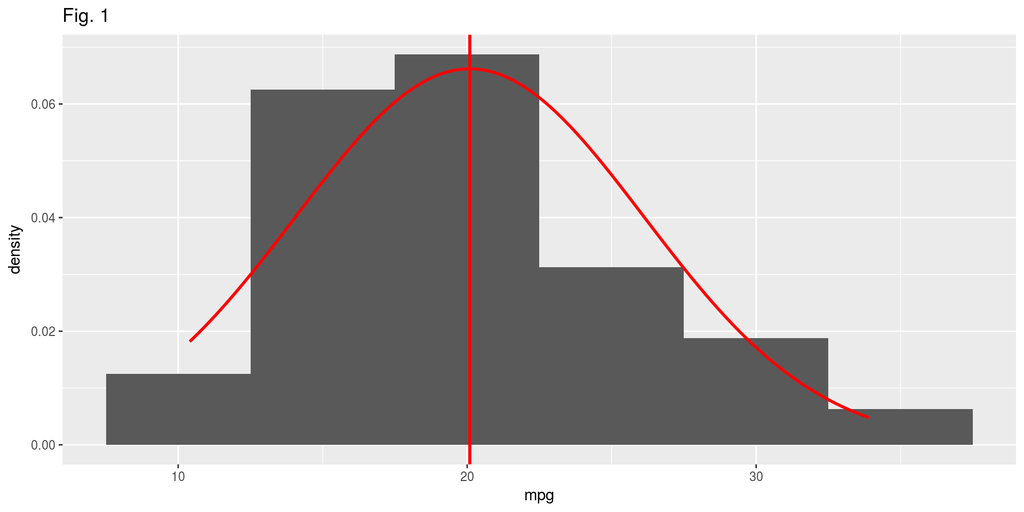

```r
# plot histogram
qplot(mpg,data=mtcars, geom="blank")+
    geom_histogram(aes(y = ..density..),binwidth = 5)+
    stat_function(fun = dnorm, args = list(mean = mean(mtcars$mpg),sd = sd(mtcars$mpg)),
                  color = "red",lwd = 1) +
    geom_vline(aes(xintercept = mean(mtcars$mpg)),color = "red",lwd = 1) +
    ggtitle("Fig. 1")
```

## Fuel Consumption By Transmission Type

We begin by looking at what the population is for each type of transmission. **Fig. 2a** is a count of automobile models by transmission type. There is a higher incidence of models with automatic versus manual transmissions. This is in line with expectation as there has been a shift away from manual transmissions in the U.S. Since we are interested in how transmissions affect fuel consumption, we next look at their relationship. **Fig. 2b** is a plot of miles per gallon by transmission type. Our figure shows manual transmissions on average have higher miles per gallon, which translate into greater fuel efficiency. It is a common perceptions that manual transmissions are more fuel efficient, and our initial observations seem to support that perception. However, further testing is needed to confirm that there is a difference in fuel consumption between the types of transmissions.

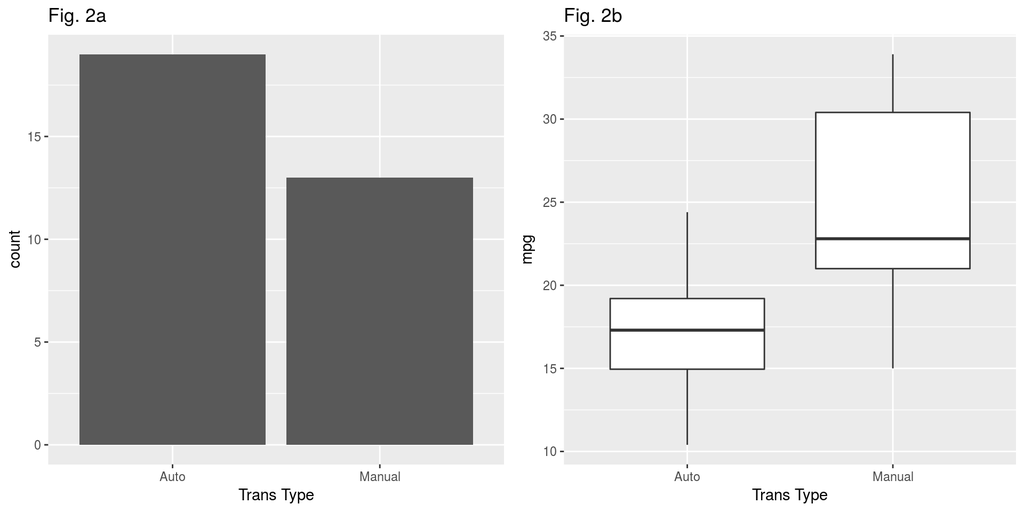

```r
# plot number of models by transmission type
plot1 <- qplot(x = factor(am,labels = c("Auto","Manual")),data = mtcars, geom="bar",
               main = "Fig. 2a", xlab = "Trans Type")

# plot miles per gallon by transmission type
plot2 <- qplot(x = factor(am,labels = c("Auto","Manual")), y = mpg, data = mtcars,
               geom = "boxplot", main = "Fig. 2b", xlab = "Trans Type")

# put plots side by side
grid.arrange(plot1,plot2,nrow = 1, ncol = 2)
```

### Test of Two Transmission Types

**Fig. 2b** shows manual transmissions have a higher fuel efficiency on average than automatic transmissions. To determine whether this difference is statistically significant, we subset our dataset into two sets based on transmission type and use a Student’s t-Test to the hypotheses:

- H0 = 0 no difference between transmission types
- Ha <> 0 a difference exists between transmission types

We assume a 95% confidence level (|p| > 0.05), and the variances for the two sets are not equal.

```r
mt <- with(mtcars,t.test(mpg[am==0],mpg[am==1]))
print(mt)
```

```
##
##  Welch Two Sample t-test
##
## data:  mpg[am == 0] and mpg[am == 1]
## t = -3.7671, df = 18.332, p-value = 0.001374
## alternative hypothesis: true difference in means is not equal to 0
## 95 percent confidence interval:
##  -11.280194  -3.209684
## sample estimates:
## mean of x mean of y
##  17.14737  24.39231
```

The p-value from our test, 0.0013736, is significant with a 95% confidence level. We therefore fail to reject the alternate hypothesis (Ha). In conclusion, the difference between both automatic and manual transmissions with regard to fuel consumption appears to hold true.

# Quantifying Fuel Consumption Differences Between Transmission Types

Our analysis next attempts to quantify the differences in fuel consumption by transmission type using a linear regression model, which explains the relationship between fuel consumption and transmission type.

### Simple Linear Regression

We begin with a simple linear regression model using fuel consumption, `mpg`, as the dependent variable and transmission type, `am`, as our independent variable. A 95% confidence level (|p| < 0.05) is assumed for our model.

```r
# simple linear regression of mpg vs transmission
fit <- lm(mpg ~ factor(am), mtcars)
summary(fit)
```

```
##
## Call:
## lm(formula = mpg ~ factor(am), data = mtcars)
##
## Residuals:
##     Min      1Q  Median      3Q     Max
## -9.3923 -3.0923 -0.2974  3.2439  9.5077
##
## Coefficients:
##             Estimate Std. Error t value            Pr(>|t|)
## (Intercept)   17.147      1.125  15.247 0.00000000000000113 ***
## factor(am)1    7.245      1.764   4.106            0.000285 ***
## ---
## Signif. codes:  0 '***' 0.001 '**' 0.01 '*' 0.05 '.' 0.1 ' ' 1
##
## Residual standard error: 4.902 on 30 degrees of freedom
## Multiple R-squared:  0.3598, Adjusted R-squared:  0.3385
## F-statistic: 16.86 on 1 and 30 DF,  p-value: 0.000285
```

The independent variable, `am`, has a p-value of 0.000285. Therefore, the variable `am` considered to be significant, with a 95% confidence level, in explaining the relationship. However, the percentage of total variability explained by our linear model is low at 0.3597989. Confounding variables may need to be considered in the relationship.

### Multivariate Linear Regression

We attempt a multivariate model that includes all variables of model design and performance in our dataset. Again, we assume a 95% confidence level (|p| > 0.05).

```r
# all variables
fit2 <- lm(mpg~., mtcars)
summary(fit2)
```

```
##
## Call:
## lm(formula = mpg ~ ., data = mtcars)
##
## Residuals:
##     Min      1Q  Median      3Q     Max
## -3.4506 -1.6044 -0.1196  1.2193  4.6271
##
## Coefficients:
##             Estimate Std. Error t value Pr(>|t|)
## (Intercept) 12.30337   18.71788   0.657   0.5181
## cyl         -0.11144    1.04502  -0.107   0.9161
## disp         0.01334    0.01786   0.747   0.4635
## hp          -0.02148    0.02177  -0.987   0.3350
## drat         0.78711    1.63537   0.481   0.6353
## wt          -3.71530    1.89441  -1.961   0.0633 .
## qsec         0.82104    0.73084   1.123   0.2739
## vs           0.31776    2.10451   0.151   0.8814
## am           2.52023    2.05665   1.225   0.2340
## gear         0.65541    1.49326   0.439   0.6652
## carb        -0.19942    0.82875  -0.241   0.8122
## ---
## Signif. codes:  0 '***' 0.001 '**' 0.01 '*' 0.05 '.' 0.1 ' ' 1
##
## Residual standard error: 2.65 on 21 degrees of freedom
## Multiple R-squared:  0.869,  Adjusted R-squared:  0.8066
## F-statistic: 13.93 on 10 and 21 DF,  p-value: 0.0000003793
```

Other variables to consider in a model are `qsec` and `hp`. However, as expected, these two variables are highly correlated.

```r
cor(mtcars$qsec,mtcars$hp)
```

```
## [1] -0.7082234
```

It is assumed horsepower would an affect the quarter mile time for an automobile. Therefore, we choose to omit `hp` from our model, since `qsec` was shown to have a more significant relationship with fuel consumption. Through model testing, we confirm the omission of `hp` is appropriate (see *Appendix, Analysis of Variance*). The result is a model with `mpg` as the dependent outcome, and the independent predictors `am`, `wt`, and `qsec`. We apply our model, assuming a 95% confidence level (|p| < 0.05).

```r
fit3 <- lm(mpg~am+wt+qsec, data = mtcars)
summary(fit3)
```

```
##
## Call:
## lm(formula = mpg ~ am + wt + qsec, data = mtcars)
##
## Residuals:
##     Min      1Q  Median      3Q     Max
## -3.4811 -1.5555 -0.7257  1.4110  4.6610
##
## Coefficients:
##             Estimate Std. Error t value   Pr(>|t|)
## (Intercept)   9.6178     6.9596   1.382   0.177915
## am            2.9358     1.4109   2.081   0.046716 *
## wt           -3.9165     0.7112  -5.507 0.00000695 ***
## qsec          1.2259     0.2887   4.247   0.000216 ***
## ---
## Signif. codes:  0 '***' 0.001 '**' 0.01 '*' 0.05 '.' 0.1 ' ' 1
##
## Residual standard error: 2.459 on 28 degrees of freedom
## Multiple R-squared:  0.8497, Adjusted R-squared:  0.8336
## F-statistic: 52.75 on 3 and 28 DF,  p-value: 0.0000000000121
```

The percentage of total variability now explained by the linear relationship is 0.8496636. Further, the p-values of 3 independent predictors indicate a significant relationship with fuel consumption. We confirm this is indeed the most appropriate model (See *Appendix, Stepwise Regression* and *Appendix, Model Diagnostics*). Our final model shows that there is a **2.9358372** mpg difference between automatic and manual transmissions.

# Appendix

### Stepwise Regression

To evaluate our selection of variables, we performed a Stepwise Regression, using a bi-directional approach, and reviewed its choice for the combination of independent variables to explain the relationship between fuel consumption and transmission type. The resulting model was the same.

```r
# stepwise approach to model selection.
step.fit <- step(lm(mpg~.,data = mtcars), trace = 0)
summary(step.fit)
```

```
##
## Call:
## lm(formula = mpg ~ wt + qsec + am, data = mtcars)
##
## Residuals:
##     Min      1Q  Median      3Q     Max
## -3.4811 -1.5555 -0.7257  1.4110  4.6610
##
## Coefficients:
##             Estimate Std. Error t value   Pr(>|t|)
## (Intercept)   9.6178     6.9596   1.382   0.177915
## wt           -3.9165     0.7112  -5.507 0.00000695 ***
## qsec          1.2259     0.2887   4.247   0.000216 ***
## am            2.9358     1.4109   2.081   0.046716 *
## ---
## Signif. codes:  0 '***' 0.001 '**' 0.01 '*' 0.05 '.' 0.1 ' ' 1
##
## Residual standard error: 2.459 on 28 degrees of freedom
## Multiple R-squared:  0.8497, Adjusted R-squared:  0.8336
## F-statistic: 52.75 on 3 and 28 DF,  p-value: 0.0000000000121
```

### Analysis of Variance

To evaluate whether to include the `hp` in our model, we perform a nested test using Analysis of Variance (anova). We assume a 95% confidence level (|F| < 0.05). Our test shows the addition of `hp` in our model is not significant in explaining the relationship with fuel consumption.

```r
fit.a <- lm(mpg~am+wt+qsec,mtcars)
fit.b <- lm(mpg~am+wt+qsec+hp,mtcars)
anova(fit.a,fit.b)
```

```
## Analysis of Variance Table
##
## Model 1: mpg ~ am + wt + qsec
## Model 2: mpg ~ am + wt + qsec + hp
##   Res.Df    RSS Df Sum of Sq      F Pr(>F)
## 1     28 169.29
## 2     27 160.07  1    9.2195 1.5551 0.2231
```

### Model Diagnostics

We run the diagnostic plots for our selected model to evaluate the residuals, and for influence and high leverage observations.

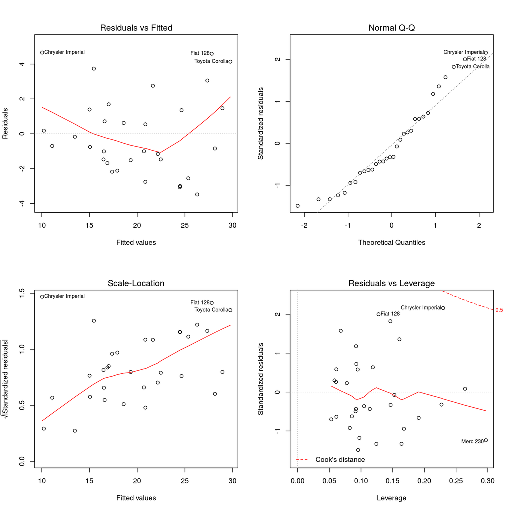

```r
# plot of diagnostics
par(mfrow=c(2,2))
plot(fit3)
```